Londogard

# Transformers From Scratch

In this post I walk through Self-Attention Transformers from scratch with demos at the end for Text Classification & Generation, where the PyTorch-code is wrapped by fast.ai to simplify end-2-end.

Feb 18, 2021 • Hampus Londögård • 31 min read

nlp machine-learning workshop

- Transformers From Scratch
  - Transformers explained
  - Self-attention
  - Understanding how it works
  - In Pytorch: basic self-attention
  - Additional Tricks
    - 1) Queries, keys & values
    - 2) Scaling the Dot Product
    - 3) Multi-head Attention
  - In Pytorch: complete self-attention
  - Building Transformers
    - The transformer block
  - Classification transformer
    - Output: producing a classifier
    - Input:Using Positions (think: ngram)We've already discussed that the current model uses embedding layer but has no sense of sequence time slotting (~ ngram).
    - PyTorch
  - Text generation transformer
  - In PyTorch
- Appendix: Demos (Text Classification & Text Generation)
  - Dependencies
  - Text Classification
    - Model (Classifier)
    - The Text Classification
  - Text Generation
    - The Model
    - The Text Generation

# Transformers From Scratch

(Open directly in Google Colab [here](https://colab.research.google.com/github/londogard/londogard/blob/master/_notebooks/2021-02-18-transformers-explained.ipynb).)

The video from the workshop (in Swedish) can be found on [YouTube](https://youtu.be/bHIU96D8SSQ).

Today I'm taking **huge inspiration from Peter Bloem** (Vrije Universiteit Amsterdam) which is a [great blog post](http://peterbloem.nl/blog/transformers) & [video lecture](https://youtu.be/KmAISyVvE1Y?list=PLIXJ-Sacf8u60G1TwcznBmK6rEL3gmZmV). It's **essentially a 80-90 % copy of the blog, with minor modifications and reworked code into TODOs** to make it more like a workshop using the Jupyter format (fitting nicely with Google Colab).  
*As demonstrations in the end I integrate PyTorch-code with fast.ai framework.*  
These demos are done to have a foundation for you to play around with as the models are not deep enough and does not train enough to really show-case the power of Transformers.

I want to note that the original blog by Peter Bloems is a work of art and does a better job at visualizing graphics in combination with text.

Finally this blog was done to support a 'Competence Night' in Machine Learning that I did @ AFRY.

## Transformers explained

> Transformers are a very exciting family of machine learning architectures. Many good tutorials exist but in the last few years, transformers have mostly become simpler, so that it is now much more straightforward to explain how modern architectures work. This post (read:Peter Bloems blog) is an attempt to explain directly how modern transformers work, and why, without some of the historical baggage. It's assumed a basic understanding of neural networks and backpropagation, for those that are not sure you can either brush up your knowledge in [this video](https://youtu.be/1NVgspM98W0) and learn how they're used today [here](https://youtu.be/DidHjsp_OV0).

Further we'll use PyTorch, with some fast.ai for the demos in appendix, to implement the full self attention & transformer module(s).

## Self-attention

The fundamental operation of any transformer architecture is the self-attention operation.

**Self-attention is a sequence-to-sequence operation**, that is we input a sequence and we have a sequence returned.  
Let's say we've got `x1..xn` as input and `y1..yn` as output where each vector is dimensioned `k`.

To produce output vector 𝐲i, the self attention operation simply takes a weighted average over all the input vectors

$y_i = \sum_{j=0}^{j=k}{w_{ij}x_j}$

Where the weights summed over $j=0..k$ is equal to $1$. $w_{ij}$ is not a parameter but is derived from a function over $x_i$ and $x_j$.  
The simplest being the dot-product.

$w_{ij}^{'} = x_i^Tx_j$

Where $x_i$ is at the same position as $y_i$ and $x_j$ traverses through all k values. For $x_{i+1}$ we get a completely different output!

Because the dot product has no bounds we apply softmax to the result, so that the whole sequence sum to $1$.

$w_{ij} = \frac{\text{exp } w_{ij}^{'}}{\sum_{j} \text{exp } w_{ij}^{'}}$

And that's really it.

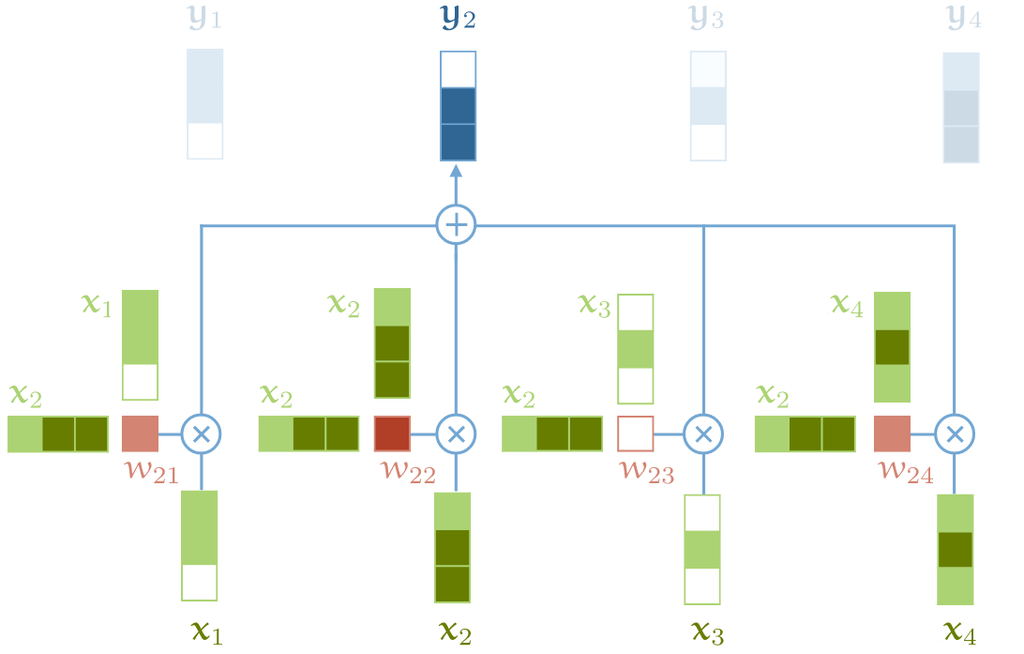

> A visual illustration of basic self-attention. Note that the softmax operation over the weights is not illustrated.

Obviously we need to apply a few more things to create a Transformer, but we'll get to that.

## Understanding how it works

As shown previously we'll use Movie Recommender system to show *why* the dot-product works.  
Say you created your manually annotated data

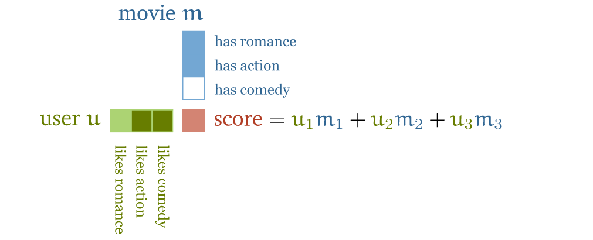

As you see, negative + negative = positive, positive + positive = positive.  
The magnitude of the score increases the final outcome.

So combining these two vectors together will work out real nice!

This might not be so practical in reality and as such we make the movie and user features *parameters* of the model. Then we ask the user for for a small number of movies they like and optimize the features so that their dot product matches the known likes.  
Even when not manually giving any features meaningful data is extracted.

Even though we don’t tell the model what any of the features should mean, in practice, it turns out that after training the features do actually reflect meaningful semantics about the movie content.

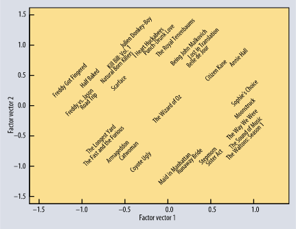

This is in essence the same as self-attention.

Using word embeddings on a sentence as

$v_{the}, v_{cat}, v_{walk}$

and feed it into self attention we get the output-vectors y,

$y_{the}, y_{cat}, y_{walk}$

where y-vectors are the *weighted sum over all embedding vectors in the first sequence*, weighted by their (normalized) dot-product with $v_{cat}$.  
E.g. $y_{the}$ = $v_{the} * v_{the} + v_{the} * v_{cat} + v_{the} * v_{walk}$.

Because *v* is learned this will continually be updated to work better. While updating how *v* is created most likely *walk* and *cat* will have a high dot-product as those are correlated.

This is the basic intuition. *Please note:*

- No parameters (yet) so the upstream mechanism creating the embeddings fully drives the self-attention by learning representations with particular dot-products
- Self-attention see the input as a *bag*, i.e. not a continuous input as it is, e.g. it is *permutation equivariant*.

## In Pytorch: basic self-attention

> What I cannot create, I do not understand *- Feynman*

The first thing we need to implement is matrix multiplications, which will be done through *torch* as native python loops are too slow.

Input:$t$ vectors, dimension $k$ and $b$ mini-batches (tensor: $b, t, k$)

We’ll represent the input, a sequence of t vectors of dimension k as a t by k matrix 𝐗. Including a minibatch dimension b, gives us an input tensor of size (b,t,k).

The set of all raw dot products w′ij forms a matrix, which we can compute simply by multiplying 𝐗 by its transpose:

Let's code!

```python
class TODO(Exception):
    """Raised when there is something TODO"""
    pass
```

```python
import torch
import torch.nn.functional as F

# assume we have some tensor x with size (b=1, t=3, k=3)
x = torch.array([[1.,2.,3.,
                 1.,2.,3.,
                 1.,2.,3.]])
```

```python
raw_weights = raise TODO("Use torch batch-matrix-multiply (bmm) to do x*x^T. Remember there's 3 dimensions!")

# Apply row-wise Softmax
weights = raise TODO("Use functional softmax to apply softmax row-wise (along which dim?)")

# creating y
y = torch.bmm(weights, x)
```

And that's it. We have created basic self-attention which is the basis of Transformers (state-of-the-art).

## Additional Tricks

To implement Transformers fully we need to add a few tricks.

### 1) Queries, keys & values

Each input-vector $x_i$ is used 3 times

1. Creating its own weight for $y_i$
2. Creating others weight for $y$ ($y_j$)
3. Used as a part of the weighted sum for each output $y$

This is often called the **query**, the **key**, and the **value** (explained later).  
We update the network to instead use *three weight-matrices*, one for each task, making it more controllable. Adding $W_k, W_q, W_v$ of size $k*k$, we've got

$q_i = W_qx_i, k_i = W_kx_i, v_i = W_vx_i$  
$w_{ij}^{'} = q_i^Tk_j$ $w_ {ij} = softmax(w_{ij}^{'})$  
$y_i = \sum_j w_{ij}v_j$

We've now given the Self Attention some controllable parameters & allows modification to the input vector to fit the task at hands.

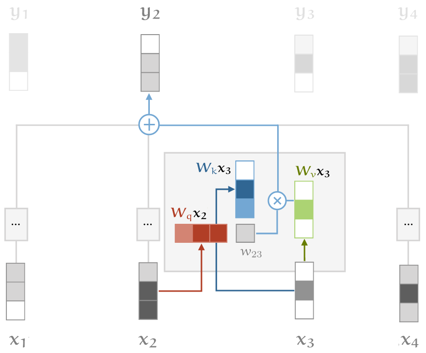

### 2) Scaling the Dot Product

Softmax can be *very sensitive to large values*, exploding gradient or making it slow to learn.  
I don't recall where but ~ 8 years ago someone figured out that scaling the value by $\frac{1}{\sqrt{k}}$ where $k$ is the embedding dimension.

$w_{ij}^{'} = \frac{q_i^Tk_j}{\sqrt{k}}$

*Why $\sqrt{k}$? Imagine a vector in $ℝk$ with values all $c$. Its Euclidean length is $\sqrt{k}c$. Therefore, we are dividing out the amount by which the increase in dimension increases the length of the average vectors.*

### 3) Multi-head Attention

The final improvement is to allow word to have different meanings with different neighbours (basically what *ngram* achieves).

By adding multiple, indexed *r*, self attention mechanisms with different matrices, $W_q^r$ etc. These are called *attention heads*.

For input $x_i$ each attention head produces a different output vector $y_i^r$. We concatenate these, and pass them through a linear transformation to reduce the dimension back to $k$. **Remember what is a linear transformation?**

**Narrow and wide self-attention**. There's two ways to apply *Multi-Head Self-Attention*.

1. (*narrow*) Cut embedding vector into chunks
   - 8 heads & $k=256$ --> 8 chunks of size 32
   - Each chunk gets Q, K, V matrices ($W_q^r$,...) ($32\times32$)
2. (*wide*) Make matrices $256\times256$ and apply each head to the whole 256-vector
   - First (*narrow*) = faster & less memory
   - Second (*wider*) = better result

Only second (*wider*) variant described.

## In Pytorch: complete self-attention

Let's make the implementation with bells & whistles.

```python
import torch
from torch import nn
import torch.nn.functional as F

class SelfAttention():
  def __init__(self, k, heads=8):
    raise TODO("Make SelfAttention a torch module (nn.Module)")
    super().__init__()
    self.k, self.heads = k, heads
```

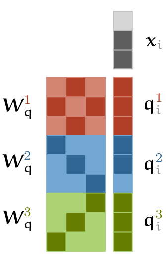

> Combining three attention heads into one matrix multiplication (for the queries).

*h* attention-heads considered as *h* separate sets of $W_q^r,W_k^r,W_v^r$, but as shown in image above **a more efficient approach is possible**.

Combine all heads into three single $k\times hk$ matrices.  
This means that we can compute the concatenated *queries*, *keys* & *values* in a single matrix multiplication.

```python
class SelfAttention(nn.Module):
  def __init__(self, k, heads=8):
    super().__init__()
    self.k, self.heads = k, heads

    # These compute the queries, keys and values for all
    # heads (as a single concatenated vector)
    self.tokeys    = raise TODO("Create a linear layer of k * hk size, no bias")
    self.toqueries = raise TODO("Create a linear layer of k * hk size, no bias")
  	self.tovalues  = raise TODO("Create a linear layer of k * hk size, no bias")

	  # This unifies the outputs of the different heads into a single k-vector
	  self.unifyheads = raise TODO("Create a linear layer of k * hk size, WITH bias")
```

From here we can implement the computation of the self-attention (`forward` function). Where we first calculate *queries, keys & values*.

```python
class SelfAttention(nn.Module):
  def __init__(self, k, heads=8):
    super().__init__()
    self.k, self.heads = k, heads

    # These compute the queries, keys and values for all
    # heads (as a single concatenated vector)
    self.tokeys    = nn.Linear(k, k * heads, bias=False)
    self.toqueries = nn.Linear(k, k * heads, bias=False)
  	self.tovalues  = nn.Linear(k, k * heads, bias=False)

	  # This unifies the outputs of the different heads into
	  # a single k-vector
	  self.unifyheads = nn.Linear(heads * k, k)

  def forward(self, x):
    b, t, k = x.size()
    h = self.heads

    queries = raise TODO("Create queries and then reshape into h separate matrices, using `view`")
    keys    = raise TODO("Create keys and then reshape into h separate matrices, using `view`")
    values  = raise TODO("Create values and then reshape into h separate matrices, using `view`")
```

Having reshaped *queries* etc from $(b,t, h*k)$ into $(b,t,h,k)$ each head has its own dimension.

The step now is to *compute dot-product for each head*.  
We can batch this if we reshape the matrices into something that's possible to batch (transposing; as head/batch is not next to each-other). **costly**

```python
class SelfAttention(nn.Module):
  def __init__(self, k, heads=8):
    super().__init__()
    self.k, self.heads = k, heads

    # These compute the queries, keys and values for all
    # heads (as a single concatenated vector)
    self.tokeys    = nn.Linear(k, k * heads, bias=False)
    self.toqueries = nn.Linear(k, k * heads, bias=False)
  	self.tovalues  = nn.Linear(k, k * heads, bias=False)

	  # This unifies the outputs of the different heads into
	  # a single k-vector
	  self.unifyheads = nn.Linear(heads * k, k)

  def forward(self, x):
    b, t, k = x.size()
    h = self.heads

    queries = self.toqueries(x).view(b, t, h, k)
    keys    = self.tokeys(x)   .view(b, t, h, k)
    values  = self.tovalues(x) .view(b, t, h, k)

    # - fold heads into the batch dimension ... contiguous = reshapes matrix in memory
    keys = keys.transpose(1, 2).contiguous().view(b * h, t, k)
    queries = queries.transpose(1, 2).contiguous().view(b * h, t, k)
    values = values.transpose(1, 2).contiguous().view(b * h, t, k)

    queries = raise TODO("Scale queries by k^(1/4)")
    keys    = raise TODO("Scale keys by k^(1/4)")

    # - get dot product of queries and keys, and scale
    dot = torch.bmm(queries, keys.transpose(1, 2))
    # - dot has size (b*h, t, k) containing raw weights

    dot = raise TODO("Normalize row-wise using F.softmax")
    # - dot now contains row-wise normalized weights

    # apply the self attention to the values
    out = torch.bmm(dot, values).view(b, h, t, k)

    # swap h, t back, unify heads
    out = out.transpose(1, 2).contiguous().view(b, t, h * k)
    return raise TODO("Unify the heads into the classes again using unifyheads")
```

And there you have it: multi-head, scaled dot-product self attention.

## Building Transformers

A transformer is not just a self-attention layer, it is an architecture.

> Any architecture designed to process a connected set of units—such as the tokens in a sequence or the pixels in an image—where the only interaction between units is through self-attention.

Like most mechanism, e.g. convolutions, a standard approach as emerged. The first step is to wrap the self-attention into a block that we can repeat.

### The transformer block

There are some variations on how to build a basic transformer block, but most of them are structured roughly like this:

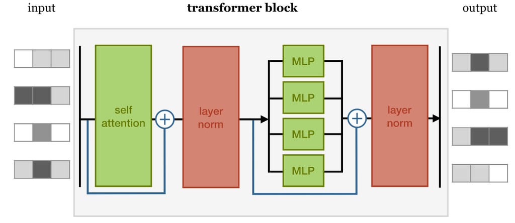

- MultiLayer Perceptron = MLP = Basic Feed-forward Neural Network
- Blue lines = Residual Connection (allow the gradient to flow through the network on a kind of "highway", making the training faster and reducing "blown up gradients")

```python
class TransformerBlock(nn.Module):
  def __init__(self, k, heads):
    super().__init__()

    self.attention = raise TODO("make a SelfAttention")

    self.norm1 = raise TODO("make a nn.LayerNorm of size k")
    self.norm2 = raise TODO("make a nn.LayerNorm of size k")

    # k * 4 is arbitrary, but needs to be larger than input/output layer (k)
    self.ff = raise TODO("create a MLP: Sequential(Linear(k, 4*k), ReLU, Linear(4*k, k))")

  def forward(self, x):
    attended = raise TODO("call your created attention on x")
    x = raise TODO("Use the first normalizer to normalizer attented+x")

    fedforward = raise TODO("Call feedforward (ff) on new x")
    return raise TODO("Finally normalize with 2nd on the addition of feedforward & x")
```

And that is really it! We have now built a Transformer Block & Self Attention.

Now we want to use it :)

## Classification transformer

The simplest classification task is a *Sequence Classifier*.  
The IMDB Review dataset is a great contender to try things out with, where each review is `positive` or `negative`.

Essentially we'll create a chain of Transformers Block and input our embedded vectors of words, and in the end transforming the output into a single value (true/false).

### Output: producing a classifier

Most common way: *Global Average Pooling* on final output sequence and map result to a *softmaxed class vector*.

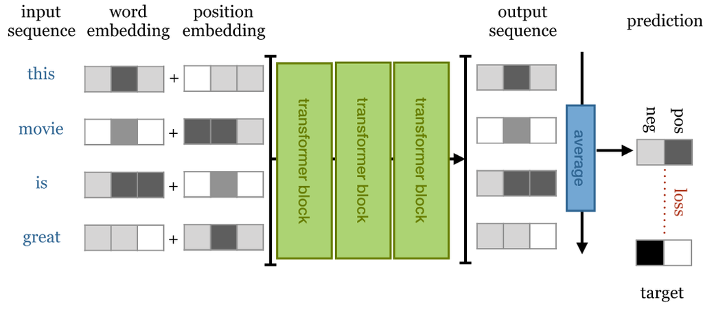

> Overview of a simple sequence classification transformer. The output sequence is averaged to produce a single vector representing the whole sequence. This vector is projected down to a vector with one element per class and softmaxed to produce probabilities.

We want our State-of-the-Art model to have a sense of order so we need to fix it.

Add a second vector of the same length as word embedding, that represent the position of the sentence+word, and add it to the word embedding. There's two ways to do this.

1. **Position Embedding** We simply embed the positions like we did the words.
   - Easy to implement
   - Works pretty good
   - Drawback is that we have to see sequences of every length during training, otherwise the position is not trained!
2. **Position Encoding** Position encodings work in the same way as embeddings, except that we don't learn the position vectors, we just choose some function $f:ℕ→ℝk$ to map the positions to real valued vectors, and let the network figure out how to interpret these encodings.
   - E.g. sin/cos
   - Works with longer sequences than seen (might not work well, but it works!)
   - Drawback: choice of encoding function is a complicated hyperparameter, and more complicated implementation.

For this tutorial the **Position Embedding** is used.

### PyTorch

Let's implement this!

```python
class Transformer(nn.Module):
    def __init__(self, k, heads, depth, seq_length, num_tokens, num_classes):
        super().__init__()

        self.num_tokens = num_tokens
        self.token_emb = raise TODO("Create a Embedding layer (nn.X) with num_tokens & k")
        self.pos_emb = raise TODO("Create Embedding Layer with seq_length & k")

        # The sequence of transformer blocks that does all the
        # heavy lifting
        blocks = []
        for i in range(depth):
            raise TODO("Append a TransformerBlock we recently created for each loop; and why not use list-comprehension?")
        self.t_blocks = raise TODO("Now make them a Sequential layer (*list = spread)")

		    # Maps the final output sequence to class logits
        self.to_probs = raise TODO("To get class logits we simply use a Linear layer of k * num_classes")

    def forward(self, x):
        """
        :param x: A (b, t) tensor of integer values representing
                  words (in some predetermined vocabulary).
        :return: A (b, c) tensor of log-probabilities over the
                 classes (where c is the nr. of classes).
        """
		    # generate token embeddings
        tokens = raise TODO("Embedd the tokens")
        b, t, k = tokens.size()

		    # generate position embeddings
		    positions = torch.arange(t)
        positions = self.pos_emb(positions)[None, :, :].expand(b, t, k)

        x = tokens + positions
        x = raise TODO("Run the network through the tranformer blocks")

        # Average-pool over the t dimension and project to class
        # probabilities
        x = raise TODO("Use the probability function, but first take the mean over dim=1 to average")
        return raise TODO("Use the F.log_softmax on dim=1 to normalize output!")
```

At depth 6, with a maximum sequence length of 512, this transformer achieves an accuracy of about 85%, competitive with results from RNN models, and much faster to train. To see the real near-human performance of transformers, we’d need to train a much deeper model on much more data. More about how to do that later.

## Text generation transformer

Let's move on!

In Text Generation we are not allowed to know the future during training, how else are we going to predict it? This means that we need to use an **autoregressive model**.

For Text Generation we'll train a character-to-character prediction, the input is a sequence of characters and output is the input shifted one charafter to the left.

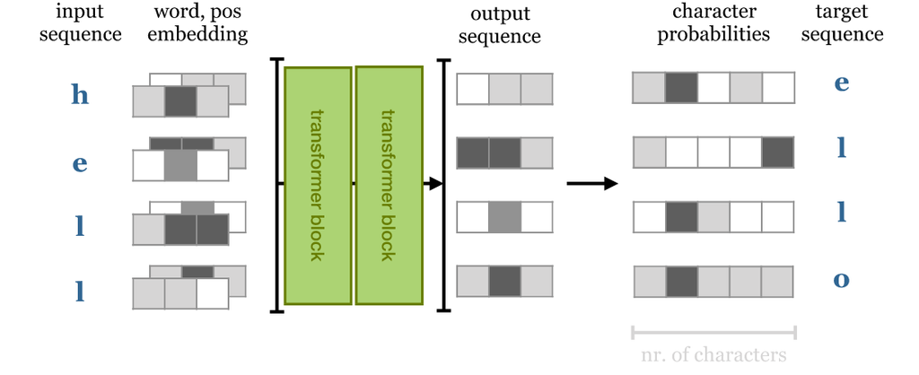

For the usual RNN this is all that is needed, but as mentioned now we need to make our model *autoregressive*, meaning that it can't look ahead.  
This is done by applying a mask which disables all elements that are ahead of current index, as in image below.

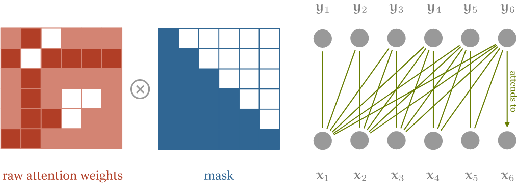

> Masking the self attention, to ensure that elements can only attend to input elements that precede them in the sequence. Note that the multiplication symbol is slightly misleading:we actually set the masked out elements (the white squares) to −∞

## In PyTorch

Implementing this in PyTorch

```python
class SelfAttentionAutoRegressive(nn.Module):
  def __init__(self, k, heads=8):
    super().__init__()
    self.k, self.heads = k, heads

    # These compute the queries, keys and values for all
    # heads (as a single concatenated vector)
    self.tokeys    = nn.Linear(k, k * heads, bias=False)
    self.toqueries = nn.Linear(k, k * heads, bias=False)
  	self.tovalues  = nn.Linear(k, k * heads, bias=False)

	  # This unifies the outputs of the different heads into
	  # a single k-vector
	  self.unifyheads = nn.Linear(heads * k, k)

  def forward(self, x):
    b, t, k = x.size()
    h = self.heads

    queries = self.toqueries(x).view(b, t, h, k)
    keys    = self.tokeys(x)   .view(b, t, h, k)
    values  = self.tovalues(x) .view(b, t, h, k)

    # - fold heads into the batch dimension ... contiguous = reshapes matrix in memory
    keys = keys.transpose(1, 2).contiguous().view(b * h, t, k)
    queries = queries.transpose(1, 2).contiguous().view(b * h, t, k)
    values = values.transpose(1, 2).contiguous().view(b * h, t, k)

    queries = queries / (k ** (1/4))
    keys    = keys / (k ** (1/4))

    # - get dot product of queries and keys, and scale
    dot = torch.bmm(queries, keys.transpose(1, 2))

    # === START OF CHANGES ===
    indices = torch.triu_indices(t, t, offset=1)
    dot[:, indices[0], indices[1]] = raise TODO("-inf; and think off what we are doing. triu_indices is shown below")
    # === END OF CHANGES ===

    # - dot has size (b*h, t, t) containing raw weights

    dot = F.softmax(dot, dim=2)
    # - dot now contains row-wise normalized weights

    # apply the self attention to the values
    out = torch.bmm(dot, values).view(b, h, t, k)

    # swap h, t back, unify heads
    out = out.transpose(1, 2).contiguous().view(b, t, h * k)
    return self.unifyheads(out)
```

```python
??torch.triu_indices
```

Once the model has been 'handicapped' as this we're ready to go!

If you'd like to learn the historical aspect of Transformers, some design consideration & more details please visit the [original blog](http://peterbloem.nl/blog/transformers) by Peter Bloem and finish that one!

I hope you found this helpful!  
**Please take a good look in Appendix for demos with Text Classification & Text Generation.**  
Do note that the depth should probably be increased as should the amount of data. Transformers improve a lot with time, depth & data (especially data!).

Thanks  
~Hampus

# Appendix: Demos (Text Classification & Text Generation)

This appendix includes one demo of each type where I've integrated the PyTorch with fast.ai to smoothen the process from model to actually using it.

**DISCLAIMER:**

- We should train on more data for a longer while to really showcase their prowess
- Use the full IMDB data to at least get a little better performance
- The demos are more wrapped code for you to play around with

With that in mind, please play around with this. Tweak parameters, add your own data and have fun!

## Dependencies

Simply run this block to

- Upgrade fastai (2.0+)
- Import fastai

```python
%%capture
!pip install -U fastai

from fastai.text.all import *
from functools import partial # Can use partial to preload a transformer block
```

## Text Classification

The Text Classification is done on the IMDB challenge. There's code included for both IMDB_SAMPLE and IMDB where the sample is a little too small to actually get good stats on.

I think adding some more depth (perhaps 6 blocks?) will increase the accuracy even further.

### Model (Classifier)

Code we already wrote for the classifier

```python
class SelfAttention(Module):
  def __init__(self, k, heads=8):
    self.k, self.heads = k, heads

    # These compute the queries, keys and values for all
    # heads (as a single concatenated vector)
    self.tokeys    = nn.Linear(k, k * heads, bias=False)
    self.toqueries = nn.Linear(k, k * heads, bias=False)
    self.tovalues  = nn.Linear(k, k * heads, bias=False)

    # This unifies the outputs of the different heads into
    # a single k-vector
    self.unifyheads = nn.Linear(heads * k, k)

  def forward(self, x):
    b, t, k = x.size()
    h = self.heads

    assert self.k == k, f'Input embedding dim ({e}) should match layer embedding dim ({self.emb})'

    queries = self.toqueries(x).view(b, t, h, k)
    keys    = self.tokeys(x)   .view(b, t, h, k)
    values  = self.tovalues(x) .view(b, t, h, k)

    # - fold heads into the batch dimension ... contiguous = reshapes matrix in memory
    keys = keys.transpose(1, 2).contiguous().view(b * h, t, k)
    queries = queries.transpose(1, 2).contiguous().view(b * h, t, k)
    values = values.transpose(1, 2).contiguous().view(b * h, t, k)

    queries = queries / (k ** (1/4))
    keys    = keys / (k ** (1/4))

    # - get dot product of queries and keys, and scale
    dot = torch.bmm(queries, keys.transpose(1, 2))

    assert dot.size() == (b*h, t, t)

    # - dot has size (b*h, t, t) containing raw weights
    dot = F.softmax(dot, dim=2)
    # - dot now contains row-wise normalized weights

    # apply the self attention to the values
    out = torch.bmm(dot, values).view(b, h, t, k)

    # swap h, t back, unify heads
    out = out.transpose(1, 2).contiguous().view(b, t, h * k)

    return self.unifyheads(out)
```

```python
class TransformerBlock(Module):
  def __init__(self, k, heads):
    super().__init__()

    self.attention = SelfAttention(k, heads=heads)

    self.norm1 = nn.LayerNorm(k)
    self.norm2 = nn.LayerNorm(k)

    self.ff = nn.Sequential(
      nn.Linear(k, 4 * k),
      nn.ReLU(),
      nn.Linear(4 * k, k)
    )

  def forward(self, x):
    attended = self.attention(x)
    x = self.norm1(attended + x)

    fedforward = self.ff(x)
    return self.norm2(fedforward + x)
```

```python
class Transformer(Module):
    def __init__(self, k, heads, depth, seq_length, num_tokens, num_classes, device):
        super().__init__()

        self.device = device
        self.seq_length = seq_length
        self.num_tokens = num_tokens
        self.token_emb = nn.Embedding(num_tokens, k)
        self.pos_emb = nn.Embedding(seq_length, k)

		    # The sequence of transformer blocks that does all the
        # heavy lifting
        tblocks = [TransformerBlock(k=k, heads=heads) for x in range(depth)]
        self.tblocks = nn.Sequential(*tblocks)

		    # Maps the final output sequence to class logits
        self.toprobs = nn.Linear(k, num_classes)

    def forward(self, x):
        """
        :param x: A (b, t) tensor of integer values representing
                  words (in some predetermined vocabulary).
        :return: A (b, c) tensor of log-probabilities over the
                 classes (where c is the nr. of classes).
        """
		    # generate token embeddings
        # x = x.split(' ')
        x = x[:,:self.seq_length,]

        tokens = self.token_emb(x)
        b, t, k = tokens.size()
        # print(b, t, k)

        # generate position embeddings
        positions = torch.arange(t, device=self.device)
        positions = self.pos_emb(positions)[None, :, :].expand(b, t, k)

        x = tokens + positions
        x = self.tblocks(x)

        # Average-pool over the t dimension and project to class
        # probabilities
        x = self.toprobs(x.mean(dim=1))
        return F.log_softmax(x, dim=1)
```

### The Text Classification

- Data Collection
- Training Loop
- Validation

```python
path = untar_data(URLs.IMDB)
path.ls()
```

```
(#7) [Path('/root/.fastai/data/imdb/README'),Path('/root/.fastai/data/imdb/unsup'),Path('/root/.fastai/data/imdb/train'),Path('/root/.fastai/data/imdb/test'),Path('/root/.fastai/data/imdb/tmp_lm'),Path('/root/.fastai/data/imdb/tmp_clas'),Path('/root/.fastai/data/imdb/imdb.vocab')]
```

```python
# df = pd.read_csv(path/'texts.csv');df.head(2)
# dls = TextDataLoaders.from_df(df, path=path, text_col='text', label_col='label', valid_col='is_valid')
```

```python
db = DataBlock(
    blocks = (TextBlock.from_folder(path, max_vocab=10_000, seq_len=256), CategoryBlock),
    get_items=get_text_files,
    splitter=GrandparentSplitter(valid_name='test'),
    get_y=parent_label
)

dls = db.dataloaders(path, path = path)
```

```python
dls.show_batch(max_n=2)
```

|  | text | category |
| --- | --- | --- |
| 0 | xxbos xxmaj raising xxmaj victor xxmaj vargas : a xxmaj review \n\n xxmaj you know , xxmaj raising xxmaj victor xxmaj vargas is like sticking your hands into a big , xxunk bowl of xxunk . xxmaj it 's … | negative |
| 1 | xxbos xxup the xxup shop xxup around xxup the xxup corner is one of the xxunk and most feel - good romantic comedies ever made . xxmaj there 's just no getting around that , and it 's hard to actually… | positive |

```python
len(dls.vocab[0]),dls.device,dls.one_batch()[0].size()
```

```
(10008, device(type='cuda', index=0), (64, 3345))
```

```python
learn = Learner(dls, Transformer(k=256, heads=8, depth=4, seq_length=256, num_tokens=len(dls.vocab[0]), num_classes=2, device=dls.device), metrics=[accuracy])
```

```
SuggestedLRs(lr_min=5.754399462603033e-05, lr_steep=0.6309573650360107)
```

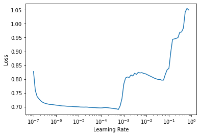

```python
learn.lr_find()
```

```python
learn.fit_one_cycle(6, 5.7e-5) # We can increase depth & more to improve the result
```

| epoch | train_loss | valid_loss | accuracy | time |
| --- | --- | --- | --- | --- |
| 0 | 0.652948 | 0.627165 | 0.656120 | 04:00 |
| 1 | 0.580878 | 0.548993 | 0.722400 | 04:08 |
| 2 | 0.481650 | 0.492818 | 0.760320 | 04:09 |
| 3 | 0.458933 | 0.472389 | 0.770200 | 04:09 |
| 4 | 0.432385 | 0.461327 | 0.778800 | 04:10 |
| 5 | 0.409607 | 0.460612 | 0.780320 | 04:08 |

Fast.AI approach

```python
learn = text_classifier_learner(dls, AWD_LSTM, drop_mult=0.5, metrics=accuracy)
learn.fine_tune(4, 1e-2)
```

| epoch | train_loss | valid_loss | accuracy | time |
| --- | --- | --- | --- | --- |
| 0 | 0.624490 | 0.643156 | 0.625000 | 00:12 |

[output not shown]

```python
learn.show_results()
```

## Text Generation

First of we generate text based on the IMDB dataset, but then we've also got the shakespeare txt file afterwards for personal testing :)

### The Model

Code we've done, the essential model

```python
class SelfAttentionAutoRegressive(Module):
  def __init__(self, k, heads=8):
    self.k, self.heads = k, heads

    # These compute the queries, keys and values for all
    # heads (as a single concatenated vector)
    self.tokeys    = nn.Linear(k, k * heads, bias=False)
    self.toqueries = nn.Linear(k, k * heads, bias=False)
    self.tovalues  = nn.Linear(k, k * heads, bias=False)

	  # This unifies the outputs of the different heads into
    # a single k-vector
    self.unifyheads = nn.Linear(heads * k, k)

  def forward(self, x):
    b, t, k = x.size()

    h = self.heads

    queries = self.toqueries(x).view(b, t, h, k)
    keys    = self.tokeys(x)   .view(b, t, h, k)
    values  = self.tovalues(x) .view(b, t, h, k)

    # - fold heads into the batch dimension ... contiguous = reshapes matrix in memory
    keys = keys.transpose(1, 2).contiguous().view(b * h, t, k)
    queries = queries.transpose(1, 2).contiguous().view(b * h, t, k)
    values = values.transpose(1, 2).contiguous().view(b * h, t, k)

    queries = queries / (k ** (1/4))
    keys    = keys / (k ** (1/4))

    # - get dot product of queries and keys, and scale
    dot = torch.bmm(queries, keys.transpose(1, 2))

    indices = torch.triu_indices(t, t, offset=1, device='cuda') # ---OBS--- this also changed
    dot[:, indices[0], indices[1]] = float('-inf')

    # - dot has size (b*h, t, t) containing raw weights

    dot = F.softmax(dot, dim=2)
    # - dot now contains row-wise normalized weights

    # apply the self attention to the values
    out = torch.bmm(dot, values).view(b, h, t, k)

    # swap h, t back, unify heads
    out = out.transpose(1, 2).contiguous().view(b, t, h * k)
    return self.unifyheads(out)
```

```python
class TransformerBlock(Module):
  def __init__(self, k, heads):
    super().__init__()

    self.attention = SelfAttentionAutoRegressive(k, heads=heads)

    self.norm1 = nn.LayerNorm(k)
    self.norm2 = nn.LayerNorm(k)

    self.ff = nn.Sequential(
      nn.Linear(k, 4 * k),
      nn.ReLU(),
      nn.Linear(4 * k, k)
    )

  def forward(self, x):
    attended = self.attention(x)
    x = self.norm1(attended + x)

    fedforward = self.ff(x)
    return self.norm2(fedforward + x)
```

```python
class Transformer(Module):
    def __init__(self, k, heads, depth, seq_length, num_tokens, device):
        super().__init__()

        self.device = device
        self.seq_length = seq_length
        self.num_tokens = num_tokens
        self.token_emb = nn.Embedding(num_tokens, k)
        self.pos_emb = nn.Embedding(seq_length, k)

		    # The sequence of transformer blocks that does all the
        # heavy lifting
        tblocks = [TransformerBlock(k=k, heads=heads) for x in range(depth)]
        self.tblocks = nn.Sequential(*tblocks)

		    # Maps the final output sequence to class logits
        self.toprobs = nn.Linear(k, num_tokens)

    def forward(self, x):
        """
        :param x: A (b, t) tensor of integer values representing
                  words (in some predetermined vocabulary).
        :return: A (b, c) tensor of log-probabilities over the
                 classes (where c is the nr. of classes).
        """

        # generate token embeddings
        # print(x.size())

        tokens = self.token_emb(x)
        b, t, k = tokens.size()
        # print(b, t, k)

        # generate position embeddings
        positions = torch.arange(t, device=self.device)
        positions = self.pos_emb(positions)[None, :, :].expand(b, t, k)

        x = tokens + positions
        x = self.tblocks(x)

        # Average-pool over the t dimension and project to class
        # probabilities
        x = self.toprobs(x.view(b*t, k)).view(b, t, self.num_tokens)
        # print(x.size())
        return F.log_softmax(x, dim=2)
```

### The Text Generation

- Data Collection
- Training Loop
- Validation

```python
path = untar_data(URLs.IMDB_SAMPLE)
path.ls()
```

```
(#2) [Path('/root/.fastai/data/imdb_sample/texts.csv'),Path('/root/.fastai/data/imdb_sample/models')]
```

```python
df = pd.read_csv(path/'texts.csv')
```

```python
df.head(1)
```

|  | label | text | is_valid |
| --- | --- | --- | --- |
| 0 | negative | Un-bleeping-believable! Meg Ryan doesn't even look her usual pert lovable self in this, which normally makes me forgive her shallow ticky acting schtick. Hard to believe she was the producer on this d… | False |

```python
dls = TextDataLoaders.from_df(df, path=path, text_col='text', is_lm=True, valid_col='is_valid', seq_len=256)
```

```python
dls.show_batch(max_n=1)
```

|  | text | text_ |
| --- | --- | --- |
| 0 | xxbos i enjoyed this movie . xxmaj unlike like some of the xxunk up , xxunk trash that is passed off as action movies , xxmaj playing xxmaj god is simple and realistic , with characters that are belie… | i enjoyed this movie . xxmaj unlike like some of the xxunk up , xxunk trash that is passed off as action movies , xxmaj playing xxmaj god is simple and realistic , with characters that are believable … |

```python
len(dls.vocab),dls.one_batch()[0].size()
```

```
(7080, (64, 256))
```

```python
learn = Learner(dls, Transformer(k=256, heads=8, depth=3, seq_length=256, num_tokens=len(dls.vocab), device=dls.device), loss_func=CrossEntropyLossFlat())
```

```
SuggestedLRs(lr_min=0.02089296132326126, lr_steep=0.0014454397605732083)
```

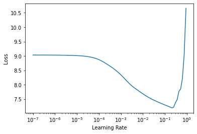

```python
learn.freeze()
learn.lr_find()
```

```python
learn.unfreeze()
```

```python
learn.fit_one_cycle(4)  # Add suggested LR if you'd like
learn.fit_one_cycle(4)
learn.fit_one_cycle(4)
```

| epoch | train_loss | valid_loss | time |
| --- | --- | --- | --- |
| 0 | 5.952718 | 6.005916 | 00:09 |
| 1 | 5.943147 | 5.950939 | 00:09 |
| 2 | 5.907956 | 5.901570 | 00:09 |
| 3 | 5.869049 | 5.870370 | 00:09 |

| epoch | train_loss | valid_loss | time |
| --- | --- | --- | --- |
| 0 | 5.782402 | 5.828668 | 00:09 |
| 1 | 5.687460 | 5.575956 | 00:09 |
| 2 | 5.571561 | 5.469945 | 00:09 |
| 3 | 5.484975 | 5.450408 | 00:09 |

| epoch | train_loss | valid_loss | time |
| --- | --- | --- | --- |
| 0 | 5.322245 | 5.439701 | 00:09 |
| 1 | 5.280037 | 5.311460 | 00:09 |
| 2 | 5.215474 | 5.259928 | 00:09 |
| 3 | 5.167902 | 5.247015 | 00:09 |

```python
def predict(self, text, n_words=1, no_unk=True, temperature=1., min_p=None, no_bar=False,
            decoder=decode_spec_tokens, only_last_word=False):
    "Return `text` and the `n_words` that come after"

    idxs = idxs_all = self.dls.test_dl([text]).items[0].to(self.dls.device)
    if no_unk: unk_idx = self.dls.vocab.index(UNK)
    for _ in (range(n_words) if no_bar else progress_bar(range(n_words), leave=False)):
        with self.no_bar(): preds,_ = self.get_preds(dl=[(idxs[None],)])
        # print(preds.size())
        res = preds[0][-1]
        if no_unk: res[unk_idx] = 0.
        if min_p is not None:
            if (res >= min_p).float().sum() == 0:
                warn(f"There is no item with probability >= {min_p}, try a lower value.")
            else: res[res < min_p] = 0.
        if temperature != 1.: res.pow_(1 / temperature)
        idx = torch.multinomial(res, 1).item()
        idxs = idxs_all = torch.cat([idxs_all, idxs.new([idx])])
        if only_last_word: idxs = idxs[-1][None]

    num = self.dls.train_ds.numericalize
    tokens = [num.vocab[i] for i in idxs_all if num.vocab[i] not in [BOS, PAD]]
    sep = self.dls.train_ds.tokenizer.sep
    return sep.join(decoder(tokens))

@delegates(Learner.get_preds)
def get_preds(self, concat_dim=1, **kwargs):
  return super().get_preds(concat_dim=concat_dim, **kwargs)
```

```python
predict(learn, "I think its a very", n_words=20, temperature=1.)
```

```
'i think its a very Who spoiler to sort with a flat in clumsy and my world to sit to american to were even'
```

```python
learn.save('gen.pkl')
```

```python
!wget https://cs.stanford.edu/people/karpathy/char-rnn/shakespear.txt
```

FastAI way

```python
predict(language_model_learner(dls, AWD_LSTM), "I think its", n_words=2, temperature=1.)
```